# ME314 Managing and Visualizing Data

## Day 3 Assignment, LSE ME314 2019

### 1. Normalizing data

This question uses this table:

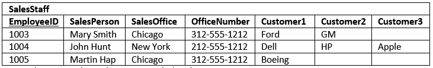

from the lecture notes. For each answer, please explain as fully as possible, and feel free to use tables or diagrams if you prefer.

1. Why does this table violate the first normal form, and what would be required to make it 1NF?

**The rules to satisfy 1st normal form are:**

- **That the data is in a database table.**
- **The table stores information in rows and columns where one or more columns, called the primary key, uniquely identify each row.**
- **Each column contains atomic values, and there are not repeating groups of columns.**

**This table violates the 1NF because it contains data customer data in more than one column, in this case, `Customer1`, `Customer2`, and `Customer3`.**

**We could solve this by moving the Customer information to its own table, and linking its primary key to a matching foreign key in the original table related to SalesStaff.**

**See [this website](https://www.essentialsql.com/get-ready-to-learn-sql-8-database-first-normal-form-explained-in-simple-english/) for more details.**

2. What additional steps would be needed to make the table 2NF, and why?

**A table is in 2nd Normal Form if:** - **The table is in 1st normal form, and** - **All the non-key columns are dependent on the table’s primary key.**

**We know that the tables are not in 1NF, but assuming that we had fixed that, there would still issues, for example, the `SalesStaff` table has two columns that do not depend on the EmployeeID: `SalesOffice` and `OfficeNumber`. We would better creating a separate table for Sales offices, and linking its primary key to the `SalesStaff` table via a matching foreign key in the `SalesStaff` table.**

**There are other potential issues that wherein, depending on how you achieved the 1NF step, there could still be table attributes that do not completely rely on that tables’s primary key. For more examples, see [here](https://www.essentialsql.com/get-ready-to-learn-sql-10-database-second-normal-form-explained-in-simple-english/).**

3. Why might we not want to normalize data to the fullest extent possible?

**Sometimes a database table that is not fully normalized still provides sufficient information for our needs, without the complexity of full normalization providing gains that outweigh the loss of simplicity. Third and higher form normalization are often ignored, for instance, for small-scale databases built for specific purposes. For large scale database scheme that need the ability to be extended easily, however, and for which data integrity is critical, full normalization is generally the best strategy.**

4. In the table below, which of the three normalization rules does this violate, if any, and why?

| countryID | countryName | EUmember | EUjoindate |
| --- | --- | --- | --- |
| 00001 | France | `true` | 1958-01-01 |
| 00004 | Hungary | `true` | 2004-05-01 |
| 00003 | Serbia | `false` | `NULL` |
| 00004 | Finland | `true` | 1995-01-01 |
| 00005 | Russia | `false` | `NULL` |
| 00006 | Ireland, UK | `true` | 1973-01-01 |

Are there any other problems with the table, besides normalization?

**Yes:**  
- **1NF is violated because because `countryName` contains multiple country values in the last row.** - **2NF is violated because we could have created a table of EU membership statuses (including soon, sadly, un-joining) that would link to the Country table via `CountryID`.** - **3NF is violates because the `EUmember` can be determined by whether the `EUjoindate` is not `NULL`.**

5. What would it take to full (1NF-3NF) normalize this dataset?

Write out these tables, and describe why this meets each of the normal forms. This is a database of movies watched on NetBricks, a streaming movie service.

| Name | Address | Movies Rented | Salutation | Category |
| --- | --- | --- | --- | --- |
| Bob Smith | 1 Houghton Street | *Star Wars*, *Inception* | Dr. | Scifi, Scifi |
| Pry Ministair | 10 Downing St | *Brexit the Movie* | Lady | Tragedy |
| Joe Bloggs | 8 Myhatt St. | *Fast and Furious 6*, *Fast and Furious 7* | Mr. | Action, Action |

**Create tables for:**

- **User, with a `UserID`, which would record the address, and salutation**
- **Movies, with a `MovieID`**
- **Categories, with a `CategoryID` linking to the Movies table**
- **Rental Table, linking to Movies and User tables, with added fields for the date rented**

```r
# create user table
user_table <- read.csv(textConnection("userid, Name, Address, Salutation
     1,     Bob Smith, 1 Houghton Street,        Dr.
     2, Pry Ministair,     10 Downing St,       Lady
     3,    Joe Bloggs,      8 Myhatt St.,        Mr."),
     stringsAsFactors = FALSE)

# comma-separated values = CSV
# we use read.csv() alongside textConnection because of the format being the same as when you read in a CSV file. we could use data.frame() as we did below, but would have to reorder the data as in its current state, it's the same as copy-pasting rows from excel, so it is easier to do it this way.


# create movies table
movie_table <- data.frame(movieid = 1:5,
                          title = c("Star Wars", "Inception", "Brexit the Movie",
                                    "Fast and Furious 6", "Fast and Furious 7"),
                          categoryid = c(1,1, 2, 3, 3),
                          stringsAsFactors = FALSE)

# create rental table
rental_table <- data.frame(userid = c(1, 1, 2, 3, 3),
                           movieid = 1:5)

# create category table
category_table <- data.frame(categoryid = 1:3,
                             genres = c("Scifi", "Tragedy", "Action"),
                             stringsAsFactors = FALSE)

# why stringsAsFactors= FALSE? let's try it with TRUE..

# anytime you have character values in a string you want to make sure you specify FALSE otherwise it will default to TRUE. Now if you have some previous experience with R, note that " The ‘factory-fresh’ default has been TRUE previously but has been changed to FALSE for R 4.0.0."
```

**Here are the four tables in fully normalized database**

#### User table

User Table

| userid | Name | Address | Salutation |
| --- | --- | --- | --- |
| 1 | Bob Smith | 1 Houghton Street | Dr. |
| 2 | Pry Ministair | 10 Downing St | Lady |
| 3 | Joe Bloggs | 8 Myhatt St. | Mr. |

#### Rental table

Rental Table

| userid | movieid |
| --- | --- |
| 1 | 1 |
| 1 | 2 |
| 2 | 3 |
| 3 | 4 |
| 3 | 5 |

#### Movie table

Movie Table

| movieid | title | categoryid |
| --- | --- | --- |
| 1 | Star Wars | 1 |
| 2 | Inception | 1 |
| 3 | Brexit the Movie | 2 |
| 4 | Fast and Furious 6 | 3 |
| 5 | Fast and Furious 7 | 3 |

#### Category table

Category Table

| categoryid | genres |
| --- | --- |
| 1 | Scifi |
| 2 | Tragedy |
| 3 | Action |

**These tables fits to the 3 levels of normalization because**

- **For achieving 1NF, the problem was the multiple rental records in each row. By separating this as the rental table and making each row correspond with a single rental record, this issue is resolved**.
- **For achieving 2NF, the partial dependency of records on the primary keys would be an issue. This could be an issue if we have both movieid and movie information in rental record because the movie information can be uniquely identified by the movie id. By separating this information into a separate table (i.e. Movie Table), this issue was resolved.**
- **For achieving 3NF, the tables should not have transitive dependency. Since the movie categories does not have any information other than the titles of categories, this cannot be an issue here unless we have a secondary key of categoryid in addition to the category name, but I created a new table categoryid just in case.**

### 2. Reshaping data

For this exercise, we will use the **nycflights13** R package, whose tables have been output in `.csv` form here. You may do the following in either R or Python. Note that this example is developed extensively in [*R for Data Science*](http://r4ds.had.co.nz/relational-data.html).

1. Create a subtable of the `flights` data, that departed before 05:53 on 2013-02-28. How many rows and columns does this subtable have?

[output not shown]

[output not shown]

```r
flights <- read.csv("nycflights13/flights.csv")
flights_sub_day <- flights %>%
    filter(year == 2013 & month == 2 & day == 28 & dep_time < 553)

sprintf("the selected data.frame has %s rows and %s columns\n",
        nrow(flights_sub), ncol(flights_sub)) %>%
    cat()
```

```
## the selected data.frame has 50996 rows and 21 columns
```

```r
nrow(flights_sub_day)
```

```
## [1] 10
```

2. Merge or join the subtable from a. `flights` data, to produce a result that includes:
- Departure time
- Carrier (two digit code, from `carrier`)
- Flight number
- Destination airport name (hint: you will need to get this from the `airports` table)

```r
airports <- read.csv("nycflights13/airports.csv")
tmp <- merge(flights_sub, airports, by.x = "dest", by.y = "faa", all.x = TRUE)
answer2 <- select(tmp, c("dep_time", "carrier", "flight", "name"))
```

3. For every airline that had flights in the `flights` data compute the average age of the planes it flew from the entire dataset. Age here will be defined as 2013 minus the `year` variable from the `planes` data. Hint: This involves a join operation on `tailnum`, but also a grouped mean to compute the age (and subtracting 2013, which you can do before or after the computation of the mean).

```r
## your code
planes <- read.csv("nycflights13/planes.csv")

tmp <- flights %>%
  filter(!duplicated(tailnum)) %>%
  select(c("tailnum", "carrier") ) %>%
  left_join(planes, by = "tailnum")

airlines <- read.csv("nycflights13/airlines.csv")

tmp %>% group_by(carrier) %>%
  summarize(mean_age = mean(2013 - year, na.rm = TRUE)) %>%
  left_join(airlines, by = "carrier") %>%
  select(c("name", "mean_age"))
```

```
## # A tibble: 16 × 2
##    name                        mean_age
##    <chr>                          <dbl>
##  1 Endeavor Air Inc.               8.29
##  2 American Airlines Inc.         25.4
##  3 Alaska Airlines Inc.            5.16
##  4 JetBlue Airways                 6.50
##  5 Delta Air Lines Inc.           17.8
##  6 ExpressJet Airlines Inc.       10.7
##  7 Frontier Airlines Inc.          5
##  8 AirTran Airways Corporation    10.8
##  9 Hawaiian Airlines Inc.          1.23
## 10 Envoy Air                      35.5
## 11 SkyWest Airlines Inc.           7.14
## 12 United Air Lines Inc.          13.1
## 13 US Airways Inc.                11.0
## 14 Virgin America                  4.29
## 15 Southwest Airlines Co.         11.0
## 16 Mesa Airlines Inc.              9.44
```

### 3. Groupwork

Get into pairs or groups and think of a research question you might have using the flights data and produce some output to discuss (no more than 2-3 minutes) at the start of the next class. (You can send the code via slack to be run by Sarah or Yuanmo or connect your own laptop.)

Consult the dplyr reference of the many functions that there are: [dplyr reference](https://dplyr.tidyverse.org/reference/index.html)

We might be interested in looking at whether the data shows a link between weather and delayed flights, so we can do a simple lot. But first we need to merge/join the merged flights/airlines data with the weather data.

However, weather only has data on three airports: EWR: Newark, NJ JFK: JFK airport in NYC  
LGA: LaGuardia Airport (also NYC)

We can merge weather data with ‘origin’ with the other merged df ‘tmp’

```r
head(flights)
```

```
##   X year month day dep_time sched_dep_time dep_delay arr_time sched_arr_time
## 1 1 2013     1   1      517            515         2      830            819
## 2 2 2013     1   1      533            529         4      850            830
## 3 3 2013     1   1      542            540         2      923            850
## 4 4 2013     1   1      544            545        -1     1004           1022
## 5 5 2013     1   1      554            600        -6      812            837
## 6 6 2013     1   1      554            558        -4      740            728
##   arr_delay carrier flight tailnum origin dest air_time distance hour minute
## 1        11      UA   1545  N14228    EWR  IAH      227     1400    5     15
## 2        20      UA   1714  N24211    LGA  IAH      227     1416    5     29
## 3        33      AA   1141  N619AA    JFK  MIA      160     1089    5     40
## 4       -18      B6    725  N804JB    JFK  BQN      183     1576    5     45
## 5       -25      DL    461  N668DN    LGA  ATL      116      762    6      0
## 6        12      UA   1696  N39463    EWR  ORD      150      719    5     58
##             time_hour
## 1 2013-01-01 05:00:00
## 2 2013-01-01 05:00:00
## 3 2013-01-01 05:00:00
## 4 2013-01-01 05:00:00
## 5 2013-01-01 06:00:00
## 6 2013-01-01 05:00:00
```

```r
# we've done this earlier
tmp <- merge(flights, airports, by.x = "dest", by.y = "faa", all.x = TRUE)

# this time we want to keep variables indicating delays and 'time_hour', which we will need along with 'origin' to match with our weather df.
airport_flights <- select(tmp, c("dep_time", "carrier", "flight", "name", "dest", "origin", "dep_delay", "arr_delay", "time_hour"))

# This lubridate function allows us to recognize the date_time column as a date_time and not character as it was before:
airport_flights$time_hour <-  as_datetime(airport_flights$time_hour)

# Read in the weather data
weather <- read.csv("nycflights13/weather.csv")
weather$time_hour <- as_datetime(weather$time_hour)

merge_dest <- weather %>%
  left_join(airport_flights, by.x = "dest", by.y = "origin")
merge_origin <- weather %>%
  full_join(airport_flights)
merge_origin <- merge_origin %>%
  select(c("origin", "temp", "humid", "wind_speed", "wind_gust", "precip", "visib", "time_hour", "dep_delay", "arr_delay")) %>%
  na.omit()

# left join 342288 -- 326089
# inner join 335563 --- 326089
# full join 343501 --- 326089
# right join 336776 --- 326089
```

First we can look at departure delay time (minutes) and wind speed

```r
# here we want to use ggplot2
library(ggplot2)
```

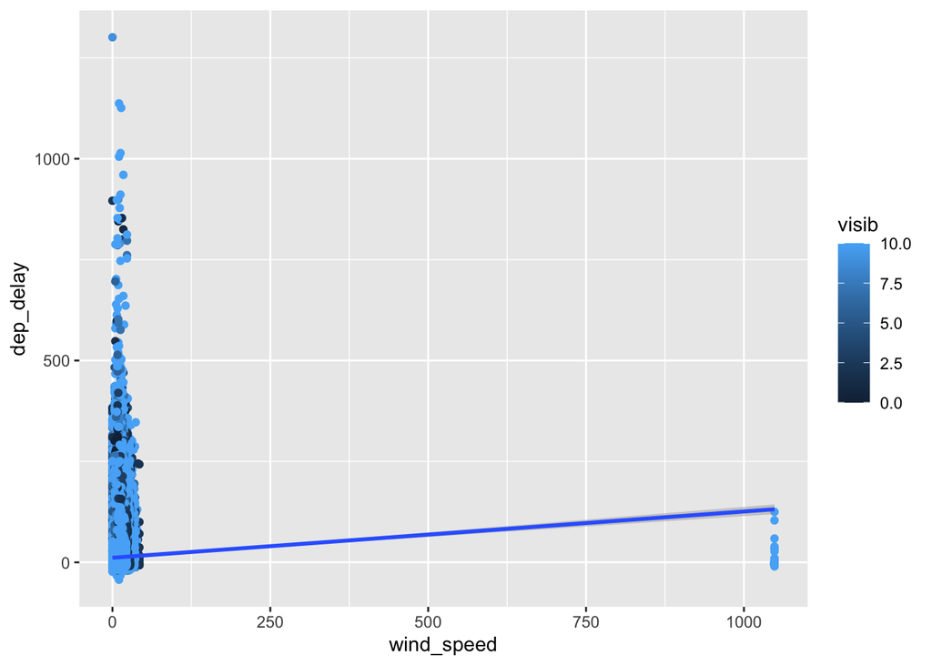

```r
#plots of the points
ggplot(merge_origin, aes(wind_speed, dep_delay, colour = visib)) +
  geom_point() +
  geom_smooth(method = lm) # regression line
```

```r
# The plots us what we can see with summary()
summary(merge_origin$wind_speed)
```

```
##     Min.  1st Qu.   Median     Mean  3rd Qu.     Max.
##    0.000    6.905    9.206   10.431   13.809 1048.361
```

Let’s drop the outliers so we can see the other data better:

```r
merge_origin_subwindspd <- subset(merge_origin, wind_speed < 1000)

# we can see that the outlier is removed in summary() output
summary(merge_origin_subwindspd$wind_speed)
```

```
##    Min. 1st Qu.  Median    Mean 3rd Qu.    Max.
##   0.000   6.905   9.206  10.326  13.809  42.579
```

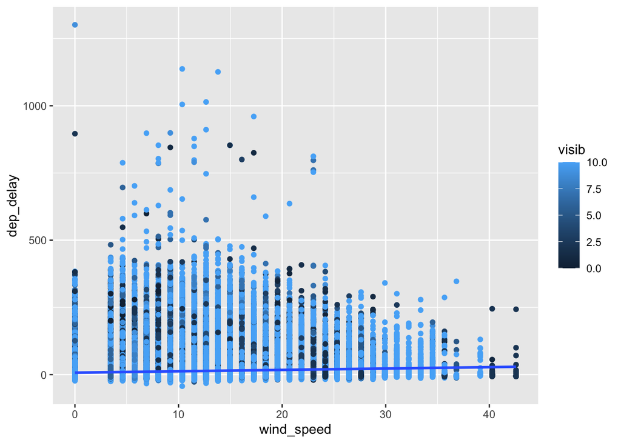

```r
# plots of the points
ggplot(merge_origin_subwindspd, aes(wind_speed, dep_delay, colour = visib)) +
  geom_point() +
  geom_smooth(method = lm) # regression line
```

```r
# see correlation
cor.test(merge_origin_subwindspd$wind_speed, merge_origin_subwindspd$dep_delay)
```

```
##
##  Pearson's product-moment correlation
##
## data:  merge_origin_subwindspd$wind_speed and merge_origin_subwindspd$dep_delay
## t = 41.272, df = 326054, p-value < 2.2e-16
## alternative hypothesis: true correlation is not equal to 0
## 95 percent confidence interval:
##  0.06867454 0.07550374
## sample estimates:
##        cor
## 0.07208999
```

We can also look at delays and precipitation:

```r
summary(merge_origin$precip)
```

```
##     Min.  1st Qu.   Median     Mean  3rd Qu.     Max.
## 0.000000 0.000000 0.000000 0.002668 0.000000 1.180000
```

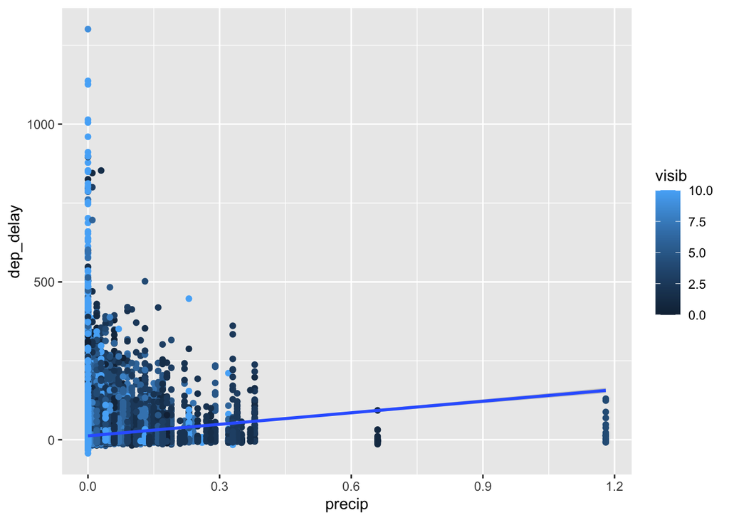

```r
#plots of the points
ggplot(merge_origin, aes(precip, dep_delay, colour = visib)) +
  geom_point() +
  geom_smooth(method = lm)
```

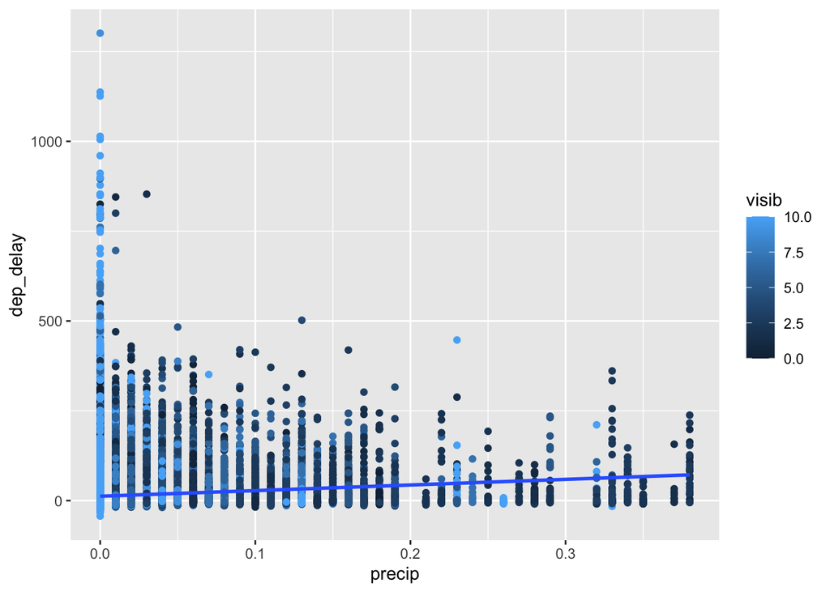

```r
precip_sub <- subset(merge_origin, precip < 0.6)

ggplot(precip_sub, aes(precip, dep_delay, colour = visib)) +
  geom_point() +
  geom_smooth(method = lm)
```

The only issue with look at this on a plot, is we don’t know how significant the correlation is. This is where today’s lecture on regression comes in, and is what you will start doing in Assignment 4. Let’s run a multiple linear regression on the data now:

```r
lm_weather <- lm(dep_delay ~ temp + humid + wind_speed + wind_gust + precip + visib, merge_origin)

summary(lm_weather)
```

```
##
## Call:
## lm(formula = dep_delay ~ temp + humid + wind_speed + wind_gust +
##     precip + visib, data = merge_origin)
##
## Residuals:
##     Min      1Q  Median      3Q     Max
## -171.61  -17.29  -11.81   -1.06 1295.14
##
## Coefficients: (1 not defined because of singularities)
##              Estimate Std. Error t value Pr(>|t|)
## (Intercept) 22.574899   0.582340  38.766  < 2e-16 ***
## temp         0.226355   0.003911  57.871  < 2e-16 ***
## humid       -0.028453   0.004260  -6.679 2.41e-11 ***
## wind_speed   0.149211   0.005916  25.220  < 2e-16 ***
## wind_gust          NA         NA      NA       NA
## precip      46.618842   3.687604  12.642  < 2e-16 ***
## visib       -2.446559   0.039854 -61.389  < 2e-16 ***
## ---
## Signif. codes:  0 '***' 0.001 '**' 0.01 '*' 0.05 '.' 0.1 ' ' 1
##
## Residual standard error: 39.55 on 326083 degrees of freedom
## Multiple R-squared:  0.02684,    Adjusted R-squared:  0.02682
## F-statistic:  1799 on 5 and 326083 DF,  p-value: < 2.2e-16
```

Hey – wind_gust is NA: multicollinearity?

Sure enough, if we run cor() we can see that wind gust and wind speed are perfectly correlated. We want linear independence here, so we will drop one of them.

```r
cor(merge_origin[sapply(merge_origin, is.numeric)])
```

```
##                    temp       humid  wind_speed   wind_gust       precip
## temp        1.000000000  0.05720729 -0.07331420 -0.07331420 -0.005331613
## humid       0.057207287  1.00000000 -0.14190147 -0.14190147  0.198290138
## wind_speed -0.073314201 -0.14190147  1.00000000  1.00000000  0.013363728
## wind_gust  -0.073314201 -0.14190147  1.00000000  1.00000000  0.013363728
## precip     -0.005331613  0.19829014  0.01336373  0.01336373  1.000000000
## visib       0.054373241 -0.52382579  0.03958199  0.03958199 -0.308494559
## dep_delay   0.089668859  0.05791814  0.03392051  0.03392051  0.060141661
## arr_delay   0.061411047  0.08056119  0.03621650  0.03621650  0.068176645
##                  visib   dep_delay   arr_delay
## temp        0.05437324  0.08966886  0.06141105
## humid      -0.52382579  0.05791814  0.08056119
## wind_speed  0.03958199  0.03392051  0.03621650
## wind_gust   0.03958199  0.03392051  0.03621650
## precip     -0.30849456  0.06014166  0.06817665
## visib       1.00000000 -0.12173539 -0.14220461
## dep_delay  -0.12173539  1.00000000  0.91486399
## arr_delay  -0.14220461  0.91486399  1.00000000
```

```r
# OR
cor(subset(merge_origin, select = c(-origin, -time_hour)))
```

```
##                    temp       humid  wind_speed   wind_gust       precip
## temp        1.000000000  0.05720729 -0.07331420 -0.07331420 -0.005331613
## humid       0.057207287  1.00000000 -0.14190147 -0.14190147  0.198290138
## wind_speed -0.073314201 -0.14190147  1.00000000  1.00000000  0.013363728
## wind_gust  -0.073314201 -0.14190147  1.00000000  1.00000000  0.013363728
## precip     -0.005331613  0.19829014  0.01336373  0.01336373  1.000000000
## visib       0.054373241 -0.52382579  0.03958199  0.03958199 -0.308494559
## dep_delay   0.089668859  0.05791814  0.03392051  0.03392051  0.060141661
## arr_delay   0.061411047  0.08056119  0.03621650  0.03621650  0.068176645
##                  visib   dep_delay   arr_delay
## temp        0.05437324  0.08966886  0.06141105
## humid      -0.52382579  0.05791814  0.08056119
## wind_speed  0.03958199  0.03392051  0.03621650
## wind_gust   0.03958199  0.03392051  0.03621650
## precip     -0.30849456  0.06014166  0.06817665
## visib       1.00000000 -0.12173539 -0.14220461
## dep_delay  -0.12173539  1.00000000  0.91486399
## arr_delay  -0.14220461  0.91486399  1.00000000
```

```r
lm_weather <- lm(dep_delay ~ temp + humid + wind_speed + precip + visib, merge_origin)

summary(lm_weather)
```

```
##
## Call:
## lm(formula = dep_delay ~ temp + humid + wind_speed + precip +
##     visib, data = merge_origin)
##
## Residuals:
##     Min      1Q  Median      3Q     Max
## -171.61  -17.29  -11.81   -1.06 1295.14
##
## Coefficients:
##              Estimate Std. Error t value Pr(>|t|)
## (Intercept) 22.574899   0.582340  38.766  < 2e-16 ***
## temp         0.226355   0.003911  57.871  < 2e-16 ***
## humid       -0.028453   0.004260  -6.679 2.41e-11 ***
## wind_speed   0.149211   0.005916  25.220  < 2e-16 ***
## precip      46.618842   3.687604  12.642  < 2e-16 ***
## visib       -2.446559   0.039854 -61.389  < 2e-16 ***
## ---
## Signif. codes:  0 '***' 0.001 '**' 0.01 '*' 0.05 '.' 0.1 ' ' 1
##
## Residual standard error: 39.55 on 326083 degrees of freedom
## Multiple R-squared:  0.02684,    Adjusted R-squared:  0.02682
## F-statistic:  1799 on 5 and 326083 DF,  p-value: < 2.2e-16
```